# ANOVA Practice Solutions

```r
library(tidyverse)
```

## 1. Training Program

First I’ll import the `TrainingProgram` dataset. I’ll `attach` it so its easy to refer to the columns, then I’ll look at the first few rows.

```r
TrainingProgram <- read_csv("TrainingProgram.csv")
attach(TrainingProgram)
head(TrainingProgram)
```

```
# A tibble: 6 x 2
  Scores Exam
   <dbl> <chr>
1     66 A
2     74 A
3     59 B
4     62 B
5     82 A
6     75 A
```

**Independence** The people were randomly assigned to two training programs, so the samples are independent.

**Normality** We can use boxplots to help us decide if the distributions seem approximately symmetric.

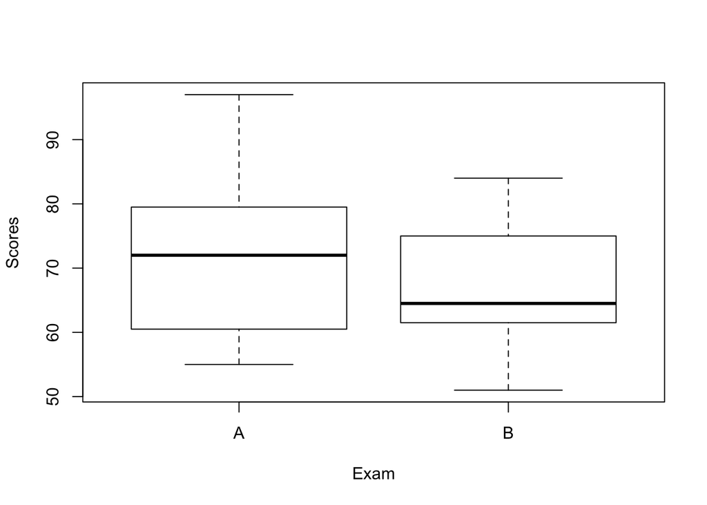

```r
boxplot(Scores ~ Exam)
```

Both seem reasonably symmetric with no outliers, so we can assume they are approximately normal.

**Standard Deviations** remember the `tapply` command

```r
tapply(Scores, Exam, sd)
```

```
        A         B
11.671725  9.099222
```

these are fine.

Now run the test.

```r
myAnalysis <- aov(Scores ~ Exam)
summary(myAnalysis)
```

```
            Df Sum Sq Mean Sq F value Pr(>F)
Exam         1    144   144.5   1.319   0.26
Residuals   30   3285   109.5
```

The p-value is rather large, so we do not have evidence that the mean scores are different in the two groups.

## Aisle location

Import the dataset, `attach` it, look at the first few rows.

```r
AisleLocation <- read_csv("AisleLocation.csv")
attach(AisleLocation)
head(AisleLocation)
```

```
# A tibble: 6 x 2
   Time Location
  <dbl> <chr>
1   8.6 Top
2   7.2 Top
3   6.2 Top
4   5.4 Top
5   5   Top
6   4   Top
```

**Independence** Seems a reasonable assumption since subjects were assigned randomly.

**Normality** Let’s check boxplots.

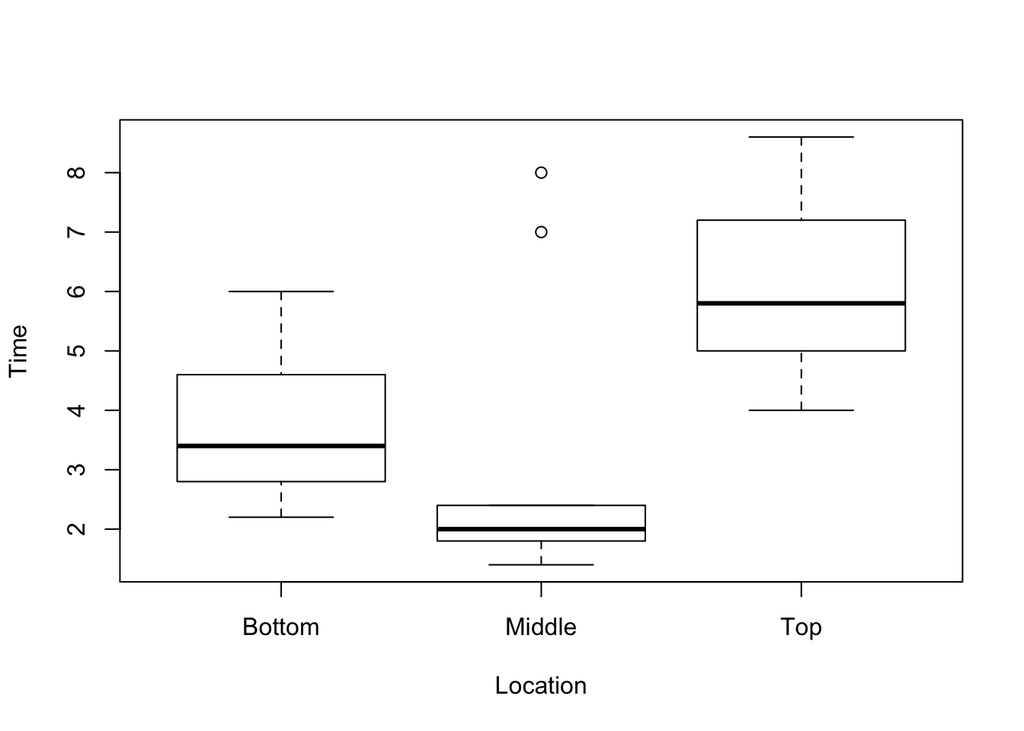

```r
boxplot(Time ~ Location)
```

The `Middle` category does not look at all normal. It is not symmetric and has some outliers. I don’t think the normality assumption is met, so we cannot use the ANOVA test.

I would recommend we collect more data with more subjects if possible.

## New Packaging

Import the dataset, `attach` it, look at the first few rows.

```r
Packaging <- read_csv("Packaging.csv")
attach(Packaging)
head(Packaging)
```

```
# A tibble: 6 x 2
  Rating Design
   <dbl> <chr>
1    6.7 New
2    8.6 New
3    6.2 New
4    7.6 New
5    6.1 New
6    5.8 New
```

**Independence** Seems a reasonable assumption since subjects were assigned randomly.

**Normality** Let’s check boxplots.

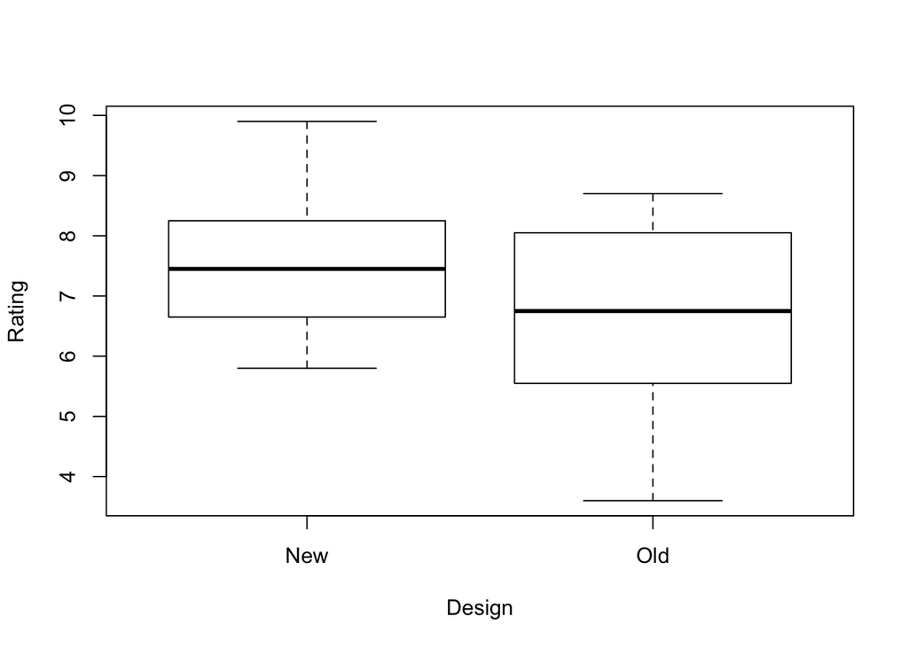

```r
boxplot(Rating ~ Design)
```

`Old` might have a slight skew, but both are reasonably symmetric, so we are ok with the normality assumption.

**Standard Deviations**

```r
tapply(Rating, Design, sd)
```

```
     New      Old
1.157129 1.504686
```

These are fine.

Now run the test

```r
packageAnalysis <- aov(Rating ~ Design)
summary(packageAnalysis)
```

```
            Df Sum Sq Mean Sq F value Pr(>F)
Design       1   8.56   8.556   4.749 0.0356 *
Residuals   38  68.46   1.802
---
Signif. codes:  0 '***' 0.001 '**' 0.01 '*' 0.05 '.' 0.1 ' ' 1
```

The p-value is less than 0.05, so we have some moderate evidence that there is a difference in the mean values between the two package designs.